# Prevalence of Dietary Supplement Use in the U.S. Latinx Population, 2021-2023

Author

Brandy Recio

## Introduction

Adults Latinx in the U.S. aged 20+ years are less likely to be insured, use prescription medications, and take any dietary supplement compared to Non-Hispanic White populations. However, while dietary supplements are widely available over-the-counter in the U.S. without the need for any doctor’s prescription to both insured and uninsured populations; It is not known whether dietary supplements are used more frequently by Latinx without access to prescription medications or health insurance. Thus, I hypothesize that Latinx that don’t have access to healthcare, due to lack of health insurance and who don’t have the monetary means to afford out-of pocket medications, rely more on dietary supplements as a substitute for prescription medications or as disease prevention.

**Objective:** to investigate the prevalence of dietary supplement use among adults Latinx vs Non-Hispanic White populations, and characterize the relationship with insurance coverage, prescription medication use, and poverty level (financial status).

**Question**

What was the prevalence of dietary supplement use by health insurance, prescription medication, and poverty level among adult Latinx compared to Non-Hispanic White populations in the U.S. from 2021 to 2023?

## Methods

- DATA PREPARATION

```r
#These are the packages needed
library(tidyverse)
library(survey)
library(broom)
library(kableExtra)
library(knitr)
library(readxl)
library(writexl)
library(scales)

###NHANES has different datasets based on population characteritics. In this study, we need only 5 that will inform my research question. Thus, I needed to merge these 5 datasets into one by SEQN which is the participant unique ID. And only keep variables that I will use.

#Step 1: import data
DEMO <- read_excel("DEMO.xlsx")
Total <- read_excel("Total.xlsx")
Health_insurance <- read_excel("Health insurance 2021-2023.xlsx")
Income <- read_excel("family_income.xlsx")
Prescription_Med <- read_excel("Prescription_meds.xlsx")

#Step 2: Participant level, unique observations throughout by SEQN (participant ID)
merged_dataset <- DEMO %>%
  select(SEQN, RIDAGEYR, RIDRETH3, SDMVPSU, SDMVSTRA, WTINT2YR) %>%
  distinct(SEQN, .keep_all = TRUE) %>%
  left_join(Total %>% select(SEQN, DSD010) %>% distinct(SEQN, .keep_all = TRUE), by = "SEQN") %>%
  left_join(Health_insurance %>% select(SEQN, HIQ011) %>% distinct(SEQN, .keep_all = TRUE), by = "SEQN") %>%
  left_join(Prescription_Med %>% select(SEQN, RXQ033) %>% distinct(SEQN, .keep_all = TRUE), by = "SEQN") %>%
  left_join(Income %>% select(SEQN, INDFMMPC) %>% distinct(SEQN, .keep_all = TRUE), by = "SEQN")

#In total there are 10 variables in this new dataset needed to answer my question (SEQN, Age, Race, SDMVPSU, SDMVSTRA, WTINT2YR, Any_DS_last_30_days, Health_insurance, Any_Prescription_Med, and Family_poverty_level). SDMVPSU,SDMVSTRA, and WTINT2YR are necessarry for calculating weighted estimates based on cross-sectional study design using "survey" R package.

#Step 3:Cleanup, so I just see the new dataset I'm using from now on "merged_dataset" on my environment.
rm(DEMO, Income,Prescription_Med, Total, Health_insurance)

#Step 4:Rename varibles. NHANES uses numbers or codes to represent variables and categories that are not intuitive (although NHANES separately mentions what those number and codes mean). So, I renamed variables and categories so data makes more sense to me.

#Rename variables
merged_dataset <- merged_dataset %>%
  rename(Age = RIDAGEYR, Race = RIDRETH3, Any_DS_last_30_days = DSD010, Family_poverty_level = INDFMMPC, Any_Prescription_Med = RXQ033, Health_insurance = HIQ011)

#Label Age categories. I just need adults populations 20+ years of age
merged_dataset <- merged_dataset %>%
  mutate(Age = as.numeric(as.character(Age))) %>%
  filter(Age >= 20) %>%
  mutate(Age = case_when(
    Age >= 20 ~ "20+ y",
    TRUE ~ NA_character_
  ))
#label race categories
merged_dataset <- merged_dataset %>%
  mutate(Race = case_when(
    Race == 1 ~ "Mexican American",
    Race == 2 ~ "Other Hispanic",
    Race == 3 ~ "Non-Hispanic White",
    Race == 4 ~ "Non-Hispanic Black",
    Race == 6 ~ "Non-Hispanic Asian",
    Race ==7 ~ "Other race",
  ))
#label DSD010 variable categories... Have you taken any DS in the last 30 days?
merged_dataset <- merged_dataset %>%
  mutate(Any_DS_last_30_days= case_when(
    Any_DS_last_30_days == 1 ~ "yes",
    Any_DS_last_30_days == 2 ~ "no",
  ))
#label any_prescription_med variable categories... any prescription med in the last 30 days?
merged_dataset <- merged_dataset %>%
  mutate(Any_Prescription_Med= case_when(
    Any_Prescription_Med == 1 ~ "yes",
    Any_Prescription_Med == 2 ~ "no",
  ))
#Label Health insurance variable categories... have health insurance?
merged_dataset <- merged_dataset %>%
  mutate(Health_insurance= case_when(
    Health_insurance == 1 ~ "yes",
    Health_insurance == 2 ~ "no",
  ))
#Label Family poverty level categories: family income relative to federal poverty level
merged_dataset <- merged_dataset %>%
  mutate(Family_poverty_level = case_when(
    Family_poverty_level %in% c(1, 2) ~ "financially insecure",
    Family_poverty_level == 3 ~ "financially secure",
  ))

##Notes: this new dataset has 7,809 observations out of which 4,779 responded to the question "have you taken any DS in the last 30 days?" which is the primary key question, the other variables are stratifications.
```

- EXPLORATORY ANALYSIS

  ```r
  ##Data cleaning
  #Step 5: check for missing data on the key variable
  mean(is.na(merged_dataset$Any_DS_last_30_days))
  ```

  ```
  [1] 0.3880138
  ```

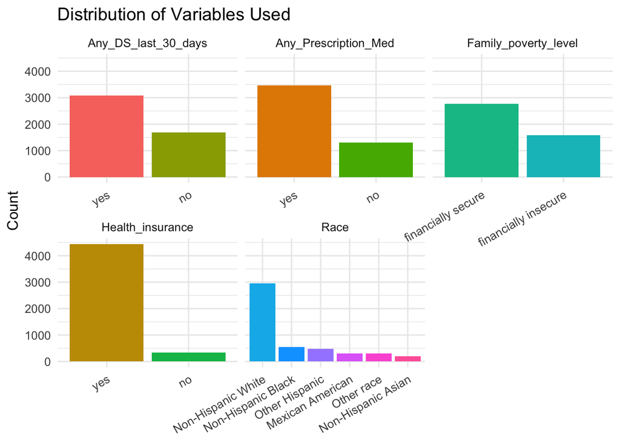

  ```r
  #this new dataset has almost 39% of data missing under Any_DS_last_30_days.

  #Step 6: remove NAs on key variable "Any_DS_last_30_days"

  merged_dataset <- merged_dataset %>%
    filter(!is.na(Any_DS_last_30_days))

  #Step 7: check the distribuiton of key variable and other relevant ones.
  merged_dataset %>%
    select(
      Any_DS_last_30_days,
      Any_Prescription_Med,
      Health_insurance,
      Family_poverty_level,
      Race) %>%
    pivot_longer(everything(), names_to = "Variable", values_to = "Value") %>%
    # standardize and drop missing or blank
    mutate(
      Value = trimws(as.character(Value)),
      Value = na_if(Value, ""),
      Value = ifelse(
        Variable %in% c("Any_DS_last_30_days", "Any_Prescription_Med", "Health_insurance"),
        tolower(Value),
        Value)) %>%
    filter(!is.na(Value)) %>%
    group_by(Variable) %>%
    mutate(Value = fct_infreq(Value)) %>%
    ungroup() %>%
    ggplot(aes(x = Value, fill = interaction(Variable, Value, drop = TRUE))) +
    geom_bar() +
    facet_wrap(~ Variable, scales = "free_x") +
    scale_x_discrete(drop = TRUE) +
    theme_minimal(base_size = 12) +
    labs(title = "Distribution of Variables Used", x = NULL, y = "Count") +
    theme(
      legend.position = "none",
      axis.text.x = element_text(angle = 30, hjust = 1))
  ```

## Results

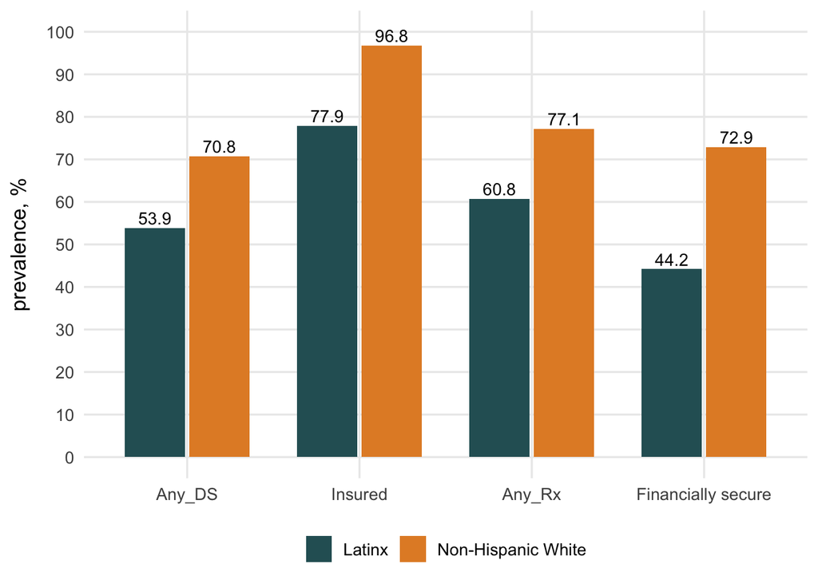

  ```r
  #Step 8: show the key variable distributions by race (Latinx are "Mexican American" and "other Hispanic" while Non-Hispanic White are just whites)

  # lc=lower case, yn=yes/no
  lc <- \(x) str_to_lower(as.character(x))
  yn <- \(x) as.integer(lc(x) == "yes")
  #data cleaning by classifying racial groups
  md<-merged_dataset %>%
    transmute(Race_clean = case_when(
        str_detect(lc(Race), "non.?hispanic.*white|white.*non.?hispanic") ~ "Non-Hispanic White",
        str_detect(lc(Race), "\\bmexican american\\b|\\bother hispanic\\b") ~ "Latinx",
        TRUE ~ NA_character_
      ) %>% fct_relevel("Latinx", "Non-Hispanic White"),
      Any_DS = yn(Any_DS_last_30_days),
      Insured = yn(Health_insurance),
      Any_Rx = yn(Any_Prescription_Med),
      `Financially secure` = case_when(
        str_detect(lc(Family_poverty_level), "financially secure")   ~ 1,
        str_detect(lc(Family_poverty_level), "financially insecure") ~ 0,
        TRUE ~ NA_real_)) %>%
    filter(!is.na(Race_clean))
  #this code computes the mean(prevalence) of each numeric column (1 is "yes", 0 is "no") per racial group
  plot_md<- md %>%
    group_by(Race_clean) %>%
    summarise(across(where(is.numeric), ~ mean(.x, na.rm = TRUE)), .groups = "drop") %>%
    pivot_longer(-Race_clean, names_to = "Indicator", values_to = "prev") %>%
    mutate(prev_pct = 100 * prev,Indicator = factor(Indicator, levels = c("Any_DS","Insured","Any_Rx","Financially secure")))
  #I want this palette
  pal <- c("Latinx" = "#2B5F64", "Non-Hispanic White" = "#E38C2E")
  ggplot(plot_md, aes(x = Indicator, y = prev_pct, fill = Race_clean)) +
    geom_col(position = position_dodge(width = 0.75), width = 0.7) +
    geom_text(aes(label = number(prev_pct, accuracy = 0.1)),
              position = position_dodge(width = 0.75), vjust = -0.3, size = 3.7) +
    scale_fill_manual(values = pal) +
    scale_y_continuous(limits = c(0, 100), breaks = seq(0, 100, 10)) +
    labs(x = NULL, y = "prevalence, %", fill = NULL) +
    theme_minimal(base_size = 13) +
    theme(
      legend.position = "bottom",
      panel.grid.minor = element_blank(),
      axis.title.y = element_text(margin = margin(r = 10)))
  ```

  Here in this plot I’m showing an updated distribution of adults Latinx and Non-Hispanic White’s characteristics based on dietary supplement use, health insurance coverage, prescription medication use, and financial security from 2021 to 2023. As you can see, Latinx populations are less likely to take any DS, be insured, take any prescription medication, and be financially secured compared to the Non-Hispanic Whites.

```r
#step 9: create a table with weighted prevalence estimates of dietary suppement use by health insurance, prescripton medication, and finanacial status. Also, provide the 95%CI and p-values comparing latinx vs Non-hispanic Whites using wald test.
md<-merged_dataset |>
  mutate(
    Race                 = as.character(Race),
    Health_insurance     = tolower(as.character(Health_insurance)),
    Any_DS_last_30_days  = tolower(as.character(Any_DS_last_30_days)),
    Any_Prescription_Med = tolower(as.character(Any_Prescription_Med)),
    Family_poverty_level = tolower(as.character(Family_poverty_level)))
md<- md |>
  mutate(
    race2 = case_when(
      Race %in% c("Mexican American", "Other Hispanic") ~ "Latinx",
      Race == "Non-Hispanic White" ~ "Non-Hispanic White",
      TRUE ~ NA_character_),
    Health_insurance = if_else(Health_insurance %in% c("yes","no"), Health_insurance, NA_character_),
    Any_DS_last_30_days = if_else(Any_DS_last_30_days %in% c("yes","no"), Any_DS_last_30_days, NA_character_),
    Any_Prescription_Med = if_else(Any_Prescription_Med %in% c("yes","no"), Any_Prescription_Med, NA_character_),
    income2 = case_when(
      Family_poverty_level == "financially secure"   ~ "Financially secure",
      Family_poverty_level == "financially insecure" ~ "Financially insecure",
      TRUE ~ NA_character_)) |>
  filter(!is.na(race2))
#survey design
options(survey.lonely.psu = "adjust")
des <- svydesign(
  id      = ~ SDMVPSU,
  strata  = ~SDMVSTRA,
  weights = ~ WTINT2YR,
  nest    = TRUE,
  data    = md)
#compute point estimates (p) and lowe/upper 95%CI
sub_by_value<- function(design, var, value) {
  v<-design$variables[[var]]
  subset(design, !is.na(v) & v == value)}
prev_ci<- function(subdes) {
  est <- svyciprop(~ I(Any_DS_last_30_days == "yes"),subdes, method = "logit", level = 0.95)
  c(p = coef(est)[1], confint(est)[1, ])}
#p-values are based on wald test. "svyglm" fits the logistic regression model using survey weights.
wald_p <- function(subdes) {
  fit <- svyglm(I(Any_DS_last_30_days == "yes") ~ factor(race2),
                design = subdes, family = quasibinomial())
  broom::tidy(fit) |>
    dplyr::filter(term == "factor(race2)Non-Hispanic White") |>
    dplyr::pull(p.value) |>
    as.numeric()}
#this code gives p%(lo-hi)
fmt <- function(p, lo, hi) sprintf("%.1f%%(%.1f–%.1f)", 100*p, 100*lo, 100*hi)
#this code gives one table row for a subgroup with 95%CI, and compute p-values
row_for <- function(var, value, label) {
  sd_all <- sub_by_value(des, var, value)
  sd_lat <- subset(sd_all, race2 == "Latinx")
  sd_nhw <- subset(sd_all, race2 == "Non-Hispanic White")

  lat <- prev_ci(sd_lat); nhw <- prev_ci(sd_nhw); pval <- wald_p(sd_all)

  tibble::tibble(
    Characteristics = label,
    `Latinx: No. of participants` = nrow(sd_lat$variables),
    `Latinx: Any DS use weighted%(95%CI)` = fmt(lat[1], lat[2], lat[3]),
    `Non-Hispanic White: No. of participants` = nrow(sd_nhw$variables),
    `Non-Hispanic White: Any DS use weighted%(95%CI)` = fmt(nhw[1], nhw[2], nhw[3]),
    `Any DS use Latinx vs NHW p-value` = sprintf("%.4f", pval))}
# building table rows
hi_yes<- row_for("Health_insurance", "yes","Yes")
hi_no  <- row_for("Health_insurance", "no", "No")
rx_yes<- row_for("Any_Prescription_Med", "yes","Yes")
rx_no <- row_for("Any_Prescription_Med", "no","No")
inc_sec <- row_for("income2", "Financially secure", "Financially secure")
inc_ins <- row_for("income2","Financially insecure","Financially insecure")

tab <- dplyr::bind_rows(hi_yes, hi_no, rx_yes, rx_no, inc_sec, inc_ins)

title_txt <- "Prevalence of Dietary Supplement (DS) use by adult Latinx and Non-Hispanic White (NHW) characteristics, 2021–2023."
#this code created a publication-style table with kable
table <- kbl(
  tab,
  booktabs   = TRUE,
  caption    = title_txt,
  align      = c("l","l","l","l","l","l"),
  col.names  = c(
    "Characteristics",
    "No. of participants", "Any DS use weighted%(95%CI)",
    "No. of participants", "Any DS use weighted%(95%CI)",
    "p-value"),
  escape     = FALSE,
  linesep    = "",
  table.attr = 'class="table table-striped" style="width:100%; table-layout:fixed;"') |>
  add_header_above(c(
    " " = 1,
    "Latinx (N=1,325)" = 2,
    "Non-Hispanic White (N=4,555)" = 2,
    " " = 1)) |>
  kable_styling(
    full_width = TRUE,
    position   = "center",
    font_size  = 12,
    bootstrap_options = c("striped")) |>
  column_spec(1, width = "17%") |>
  column_spec(2, width = "12%") |>
  column_spec(3, width = "22%") |>
  column_spec(4, width = "12%") |>
  column_spec(5, width = "22%") |>
  column_spec(6, width = "17%") |>
  group_rows("Health insurance", 1, 2) |>
  group_rows("Any prescription medication", 3, 4) |>
  group_rows("Financial status", 5, 6)
table
```

Prevalence of Dietary Supplement (DS) use by adult Latinx and Non-Hispanic White (NHW) characteristics, 2021–2023.

[output not shown]

In this table I’m showing the prevalence of dietary supplement use by adult Latinx and Non-Hispanic White (NHW) stratified by health insurance, any prescription medication and financial status from 2021 to 2023. As you can see, among the Latinx who have health insurance, 57.3% take any DS, which is statistically significantly lower than whites who have health insurance and take any DS (p<0.001). The same trend is true for the prescription medication and financial status stratification.

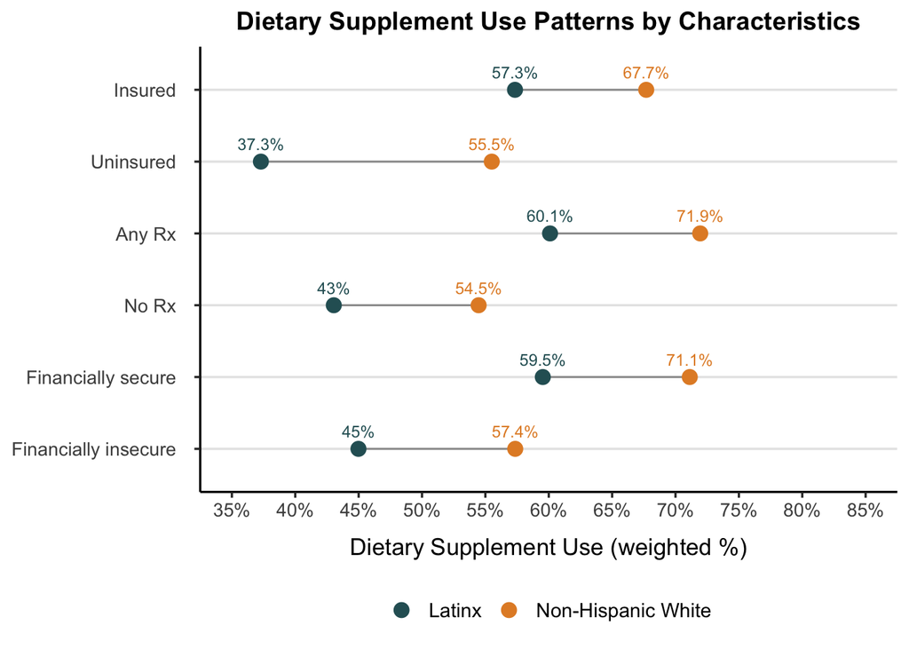

```r
#Step 10: create a plot that allow us to see the disparity among the subgroups between latinx and Non-Hispanic Whites.
md<- merged_dataset %>%
  filter(Race %in% c("Mexican American", "Other Hispanic", "Non-Hispanic White")) %>%
  mutate(Race2 = if_else(Race %in% c("Mexican American", "Other Hispanic"),"Latinx", "Non-Hispanic White"),ds = as.integer(Any_DS_last_30_days == "yes"))
#Survey design, to get the estimated national weights
des <- svydesign(
  ids     = ~ SDMVPSU,
  strata  = ~ SDMVSTRA,
  weights = ~ WTINT2YR,
  nest    = TRUE,
  data    = md)
#characteristics to compare across racial groups
y_map <- tribble(
  ~var,                 ~level,               ~y_label,
  "Health_insurance",    "yes",             "Insured",
  "Health_insurance",    "no",               "Uninsured",
  "Any_Prescription_Med","yes",               "Any Rx",
  "Any_Prescription_Med","no",                "No Rx",
  "Family_poverty_level","financially secure", "Financially secure",
  "Family_poverty_level","financially insecure","Financially insecure")
#this code gives me the survey design that only includes people who fits my categories(subset of the participants)
sub_design_eq<- function(design, var, level) {
  v<- design$variables[[var]]
  subset(design, !is.na(v) & v == level)}
#this code calculates the weighted proportion of people who used DS for each racial group for a given subgroup (insured vs uninsured for instance)
one_group<- function(var, level, y_label) {
  subdes <- sub_design_eq(des, var, level)
  est <- svyby(~ ds, ~ Race2, subdes, svymean, na.rm = TRUE)
  transmute(est, Race2, prop = ds, y_label)}
#this code combines the one_group() calcualtions for every subgroup in y_map, orders the racial groups and y-axis labeling, and creates percentages.
res<- purrr::pmap_dfr(y_map, one_group) %>%
  mutate(Race2 = factor(Race2, levels = c("Latinx","Non-Hispanic White")), y_label = fct_rev(fct_inorder(y_label)),pct_lab = paste0(round(prop * 100, 1), "%"))
#this code creates a line that connects racial groups for each stratification, to highlight the differences between them.
seg_df<- res %>%
  group_by(y_label) %>%
  summarise(xmin = min(prop, na.rm = TRUE),
            xmax = max(prop, na.rm = TRUE),
            .groups = "drop")
#I want this especific palette to be consistent with the previous barplot
pal<- c("Latinx" = "#2B5F64","Non-Hispanic White" = "#E38C2E")
ggplot() +
  geom_segment(data = seg_df,
               aes(x = xmin, xend = xmax, y = y_label, yend = y_label),
               color = "grey60", linewidth = 0.5) +
  geom_point(data = res, aes(x = prop, y = y_label, color = Race2), size = 3.5) +
  geom_text(data = res, aes(x = prop, y = y_label, label = pct_lab, color = Race2),
            vjust = -1, size = 3.2, show.legend = FALSE) +
  scale_color_manual(values = pal) +
  scale_x_continuous(labels = percent_format(accuracy = 1),
                     limits = c(0.35, 0.85),
                     breaks = seq(0.35, 0.85, 0.05)) +
  labs(
    title = "Dietary Supplement Use Patterns by Characteristics",
    x = "Dietary Supplement Use (weighted %)",
    y = NULL,
    color = NULL) +
  theme_classic(base_size = 13) +
  theme(
    panel.grid.major.y = element_line(color = "#E6E6E6"),
    panel.grid.major.x = element_blank(),
    axis.text.y        = element_text(margin = margin(r = 10)),
    legend.position    = "bottom",
    legend.title       = element_blank(),
    legend.text        = element_text(size = 11),
    plot.title         = element_text(hjust = 0.5, face = "bold", size = 14),
    axis.title.x       = element_text(margin = margin(t = 10)))
```

In this graph I’m illustrating the dietary supplement use patterns by insurance coverage, use of prescription medication, and financial security in Latinx vs Non-Hispanic Whites. You notice that Latinx are less likely to take any DS, and this is true across the board (no matter the stratification). However, within groups you also notice that the uninsured, the ones who don’t take any prescription medication, and those who are financially insecure are even less likely to take any DS than their counterpart. Thus, this data showed that my hypothesis was not substantiated for this sample.